# Final project starter script

# 1 way anova

```
##                  Df   Sum Sq     Mean Sq F value Pr(>F)
## marital.status    4 1.59e+11 39759963229   49.79 <2e-16 ***
## Residuals      4934 3.94e+12   798512530
## ---
## Signif. codes:  0 '***' 0.001 '**' 0.01 '*' 0.05 '.' 0.1 ' ' 1
## 4045 observations deleted due to missingness
```

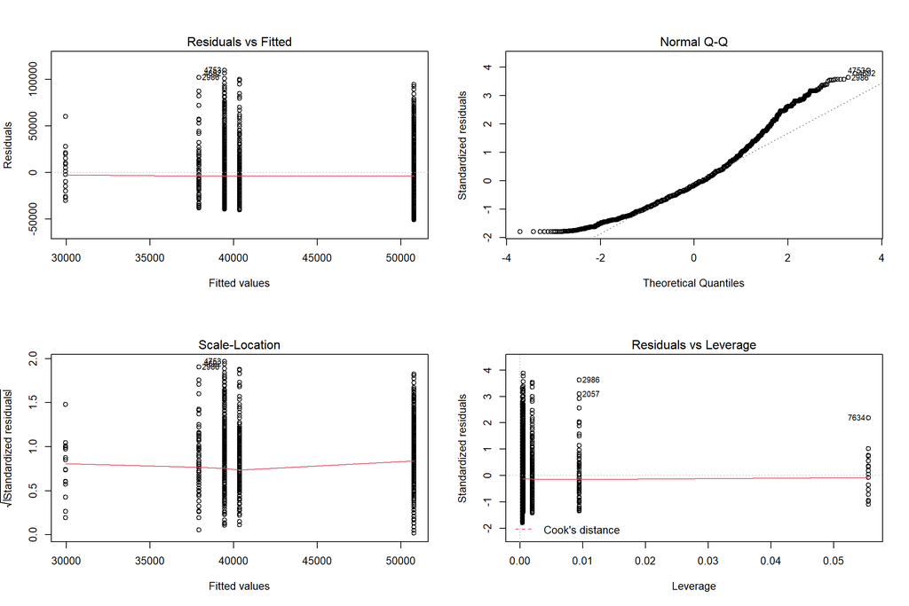

The p-value is significant at the 0 level, so the data suggests that there is an association between income and current marital status. In other words, average income varies across the five groups of marital statuses considered in the data. However we would further like to go ahead and find out if the average income varies across the marital statuses for each sex or not. We add sex variable to our model and are interested to see if there is a statistical dependence between the marital status and sex that impacs the income.

#2 way anova

```
##                  Df        Sum Sq      Mean Sq F value Pr(>F)
## marital.status    4  159039852916  39759963229   52.08 <2e-16 ***
## sex               1  173971329017 173971329017  227.89 <2e-16 ***
## Residuals      4933 3765889492743    763407560
## ---
## Signif. codes:  0 '***' 0.001 '**' 0.01 '*' 0.05 '.' 0.1 ' ' 1
## 4045 observations deleted due to missingness
```

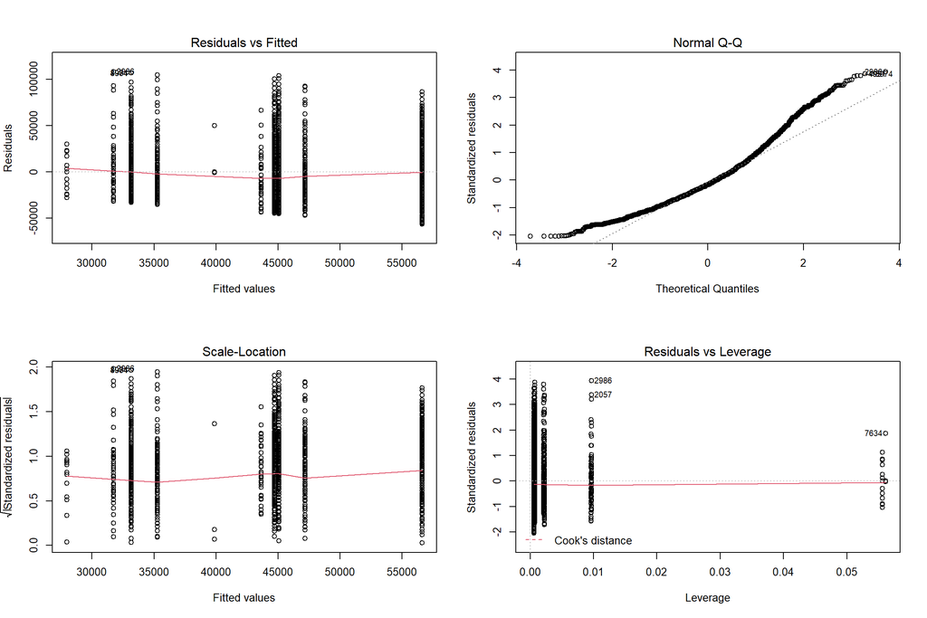

*household*

#data cleaning

```
##     Min.  1st Qu.   Median     Mean  3rd Qu.     Max.
## -5.00000  0.00000  0.00000  0.01202  2.00000  9.00000
```

```
##    Min. 1st Qu.  Median    Mean 3rd Qu.    Max.    NA's
##   1.000   2.000   3.000   3.261   4.000  15.000    1561
```

```
##    Min. 1st Qu.  Median    Mean 3rd Qu.    Max.    NA's
##   0.000   0.000   1.000   1.081   2.000   9.000    1588
```

# finding associations of houshold size with income across each group of sex

```
##
## Call:
## lm(formula = income ~ household.size, data = nlsy)
##
## Residuals:
##    Min     1Q Median     3Q    Max
## -52059 -20585  -4401  14415 107362
##
## Coefficients:
##                Estimate Std. Error t value Pr(>|t|)
## (Intercept)     55295.8      918.0   60.23   <2e-16 ***
## household.size  -3236.9      255.1  -12.69   <2e-16 ***
## ---
## Signif. codes:  0 '***' 0.001 '**' 0.01 '*' 0.05 '.' 0.1 ' ' 1
##
## Residual standard error: 28390 on 4705 degrees of freedom
##   (4277 observations deleted due to missingness)
## Multiple R-squared:  0.0331, Adjusted R-squared:  0.03289
## F-statistic:   161 on 1 and 4705 DF,  p-value: < 2.2e-16
```

```
##
## Call:
## lm(formula = income ~ household.size + sex, data = nlsy)
##
## Residuals:
##    Min     1Q Median     3Q    Max
## -56732 -19105  -4826  14897 107524
##
## Coefficients:
##                Estimate Std. Error t value Pr(>|t|)
## (Intercept)     59639.0      956.8   62.33   <2e-16 ***
## household.size  -2907.2      251.5  -11.56   <2e-16 ***
## sexFemale      -10998.3      816.2  -13.47   <2e-16 ***
## ---
## Signif. codes:  0 '***' 0.001 '**' 0.01 '*' 0.05 '.' 0.1 ' ' 1
##
## Residual standard error: 27860 on 4704 degrees of freedom
##   (4277 observations deleted due to missingness)
## Multiple R-squared:  0.06903,    Adjusted R-squared:  0.06864
## F-statistic: 174.4 on 2 and 4704 DF,  p-value: < 2.2e-16
```

```
##
## Call:
## lm(formula = income ~ household.size * sex, data = nlsy)
##
## Residuals:
##    Min     1Q Median     3Q    Max
## -53867 -19522  -4322  14620 114471
##
## Coefficients:
##                          Estimate Std. Error t value    Pr(>|t|)
## (Intercept)               55382.0     1254.4  44.150     < 2e-16 ***
## household.size            -1515.0      365.8  -4.141 0.000035161 ***
## sexFemale                 -2576.8     1804.9  -1.428       0.153
## household.size:sexFemale  -2626.8      502.5  -5.228 0.000000179 ***
## ---
## Signif. codes:  0 '***' 0.001 '**' 0.01 '*' 0.05 '.' 0.1 ' ' 1
##
## Residual standard error: 27780 on 4703 degrees of freedom
##   (4277 observations deleted due to missingness)
## Multiple R-squared:  0.07441,    Adjusted R-squared:  0.07382
## F-statistic:   126 on 3 and 4703 DF,  p-value: < 2.2e-16
```

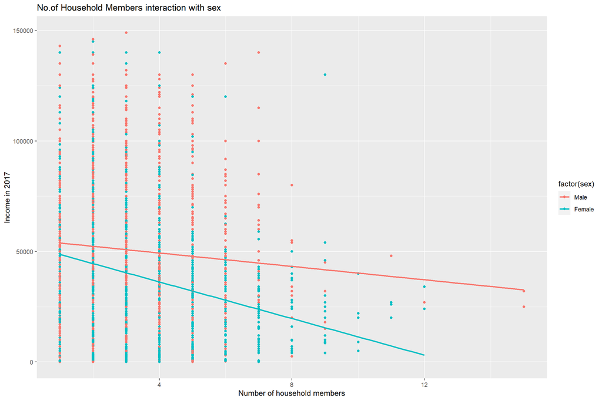

# finding associations of number of houshold members under 18 with income across each group of sex

```
##
## Call:
## lm(formula = income ~ household.under18, data = nlsy)
##
## Residuals:
##    Min     1Q Median     3Q    Max
## -49216 -20064  -4760  14936 105695
##
## Coefficients:
##                   Estimate Std. Error t value Pr(>|t|)
## (Intercept)        49215.9      535.6   91.89   <2e-16 ***
## household.under18  -4151.9      326.7  -12.71   <2e-16 ***
## ---
## Signif. codes:  0 '***' 0.001 '**' 0.01 '*' 0.05 '.' 0.1 ' ' 1
##
## Residual standard error: 28400 on 4695 degrees of freedom
##   (4287 observations deleted due to missingness)
## Multiple R-squared:  0.03326,    Adjusted R-squared:  0.03305
## F-statistic: 161.5 on 1 and 4695 DF,  p-value: < 2.2e-16
```

```
##
## Call:
## lm(formula = income ~ household.under18 + sex, data = nlsy)
##
## Residuals:
##    Min     1Q Median     3Q    Max
## -53461 -19461  -4333  14915 107083
##
## Coefficients:
##                   Estimate Std. Error t value Pr(>|t|)
## (Intercept)        53461.0      628.9   85.00   <2e-16 ***
## household.under18  -3376.0      327.6  -10.31   <2e-16 ***
## sexFemale         -10287.8      831.3  -12.38   <2e-16 ***
## ---
## Signif. codes:  0 '***' 0.001 '**' 0.01 '*' 0.05 '.' 0.1 ' ' 1
##
## Residual standard error: 27960 on 4694 degrees of freedom
##   (4287 observations deleted due to missingness)
## Multiple R-squared:  0.0638, Adjusted R-squared:  0.06341
## F-statistic:   160 on 2 and 4694 DF,  p-value: < 2.2e-16
```

```
##
## Call:
## lm(formula = income ~ household.under18 * sex, data = nlsy)
##
## Residuals:
##    Min     1Q Median     3Q    Max
## -51189 -20116  -4457  14420 116950
##
## Coefficients:
##                             Estimate Std. Error t value Pr(>|t|)
## (Intercept)                  51189.1      695.0  73.650  < 2e-16 ***
## household.under18             -536.5      499.9  -1.073    0.283
## sexFemale                    -5324.9     1059.5  -5.026 5.20e-07 ***
## household.under18:sexFemale  -4932.5      658.9  -7.486 8.45e-14 ***
## ---
## Signif. codes:  0 '***' 0.001 '**' 0.01 '*' 0.05 '.' 0.1 ' ' 1
##
## Residual standard error: 27790 on 4693 degrees of freedom
##   (4287 observations deleted due to missingness)
## Multiple R-squared:  0.07485,    Adjusted R-squared:  0.07426
## F-statistic: 126.6 on 3 and 4693 DF,  p-value: < 2.2e-16
```

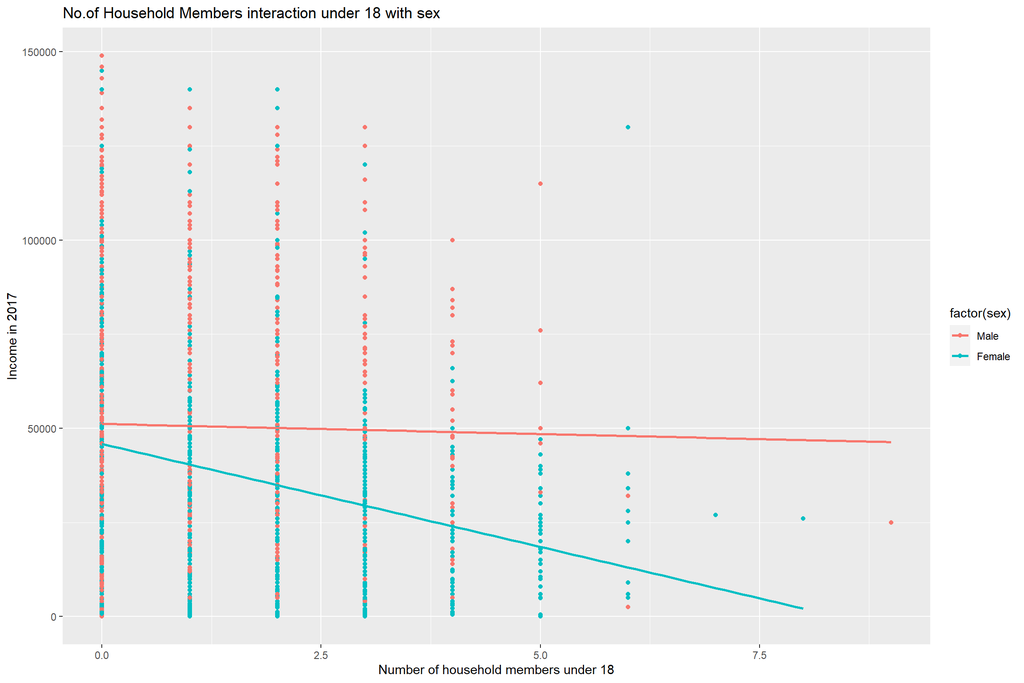

Here we carry out a linear model first to see the association of number of household members under 18 with the income. The p-value is observed to be significant. We therefore go ahead with the multiple linear regression of number of household members under 18 with the income of each sex and interaction between household size and sex.